# Deep Learning : Human Action Recognition

```python
# import the required libraries
import tensorflow as tf
from tensorflow.keras.models import Sequential
from tensorflow.keras.layers import Dense, Conv2D, MaxPooling2D, Flatten
import numpy as np
import matplotlib.pyplot as plt
import pandas as pd
import pathlib
import shutil
from keras.models import Model
import tempfile
from keras.utils.vis_utils import plot_model
#import keras_applications
from keras.applications.vgg16 import  VGG16
import tensorflow_hub as hub
import seaborn as sns
import matplotlib.pyplot as plt
sns.set_theme(style="ticks", color_codes=True)


print(tf.__version__)
```

```
2.6.0
```

```python
# mount the drive
from google.colab import drive
drive.mount('/content/drive')
```

```python
!cp /content/drive/'My Drive'/Images.zip .
!unzip -q -o Images.zip
!rm Images.zip
```

# Setup the Tensorboard

```python
logdir = pathlib.Path(tempfile.mkdtemp())/"tensorboard_logs"
shutil.rmtree(logdir, ignore_errors=True)

# Load the TensorBoard notebook extension
%load_ext tensorboard

# Open an embedded TensorBoard viewer
%tensorboard --logdir {logdir}/models
```

Plotter Function to plot the training and validation loss and accuracy

```python
from itertools import cycle
def plotter(history_hold, metric = 'binary_crossentropy', ylim=[0.0, 1.0]):
  cycol = cycle('bgrcmk')
  for name, item in history_hold.items():
    y_train = item.history[metric]
    y_val = item.history['val_' + metric]
    x_train = np.arange(0,len(y_val))

    c=next(cycol)

    plt.plot(x_train, y_train, c+'-', label=name+'_train')
    plt.plot(x_train, y_val, c+'--', label=name+'_val')

  plt.legend()
  plt.xlim([1, max(plt.xlim())])
  plt.ylim(ylim)
  plt.xlabel('Epoch')
  plt.ylabel(metric)
  plt.grid(True)
```

```python
# import the data
df = pd.read_csv('/content/drive/MyDrive/S40AR_train_data.csv')
df.head(5)
```

|  | FileName | action | action_class |
| --- | --- | --- | --- |
| 0 | Img_1000.jpg | walking_the_dog | Interacting_with_animal |
| 1 | Img_1001.jpg | riding_a_bike | other_activity |
| 2 | Img_1002.jpg | gardening | domestic_work |
| 3 | Img_1008.jpg | cooking | domestic_work |
| 4 | Img_1010.jpg | jumping | other_activity |

# Data Exploration

Exploration of the action_class

[figure not shown]

```python
labels = df.action_class.unique()
data = df.action_class.value_counts()

colors = sns.color_palette('pastel')[0:5]

#create pie chart
plt.pie(data, labels = labels, colors = colors, autopct='%.0f%%')
plt.show()
```

Analysis : From the above pie chart we can see that the number of records for the playing_musical_instrument is less compared to the other action_classes. So our model might have less accuracy on paying_musical_instrument action_class.

**Exploration of attribute action**

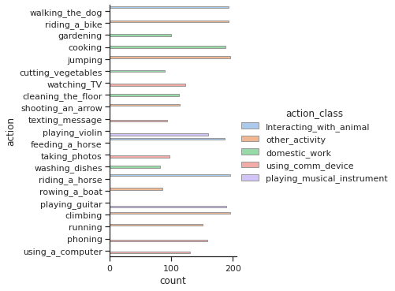

```python
sns.catplot(y="action", hue="action_class", kind="count",
            palette="pastel", edgecolor=".6",
            data=df)
```

**Label Encoder for the target variables action and action_class**

```python
# label encoding
from sklearn.preprocessing import LabelEncoder
l1 = LabelEncoder()
l2 = LabelEncoder()

# encode the labels action and action_class
df_encode = df
df_encode['action_encoded'] = l1.fit_transform(df_encode['action'])
df_encode['action_class_encoded'] = l2.fit_transform(df_encode['action_class'])
df_encode.head(5)
```

|  | FileName | action | action_class | action_encoded | action_class_encoded |
| --- | --- | --- | --- | --- | --- |
| 0 | Img_1000.jpg | walking_the_dog | Interacting_with_animal | 18 | 0 |
| 1 | Img_1001.jpg | riding_a_bike | other_activity | 10 | 2 |
| 2 | Img_1002.jpg | gardening | domestic_work | 5 | 1 |
| 3 | Img_1008.jpg | cooking | domestic_work | 2 | 1 |
| 4 | Img_1010.jpg | jumping | other_activity | 6 | 2 |

```python
# check the dtypes of all the attributes
df_encode.dtypes
```

```
FileName                object
action                  object
action_class            object
action_encoded           int64
action_class_encoded     int64
dtype: object
```

```python
# convert the dtypes of action_class_encoded and action_class_encode to string
df_encode['action_class_encoded'] = df_encode['action_class_encoded'].astype(str)
df_encode['action_encoded'] = df_encode['action_encoded'].astype(str)

# check to make sure the dtypes of the above columns are converted to string
df_encode.dtypes
```

```
FileName                object
action                  object
action_class            object
action_encoded          object
action_class_encoded    object
dtype: object
```

**Split the Dataset into train and validation**

```python
# split the dataset into features and target
x = df_encode
y_action = df_encode['action_encoded']
y_action_class = df_encode['action_class_encoded']
```

```python
# split the dataset into train,validation and test set
from sklearn.model_selection import train_test_split

# split the dataset into train dataset(70%) and remainder dataset(30%)
x_train, x_rem, y_train_action, y_rem_action , y_train_action_class, y_rem_action_class = train_test_split(x, y_action, y_action_class,train_size=0.7, shuffle=True, )

# split the remaining 30% data between validation and test set
x_val, x_test, y_val_action, y_test_action , y_val_action_class, y_test_action_class = train_test_split(x_rem, y_rem_action, y_rem_action_class ,test_size=0.5, shuffle=True, )
```

```python
# check the shape of train dataset
x_train.shape
```

```
(2121, 5)
```

```python
# check the shape of validation dataset
x_val.shape
```

```
(454, 5)
```

```python
# check the shape of test dataset
x_test.shape
```

```
(455, 5)
```

# DataLoader

```python
import tensorflow.keras as keras
from scipy.interpolate import interp1d
import numpy as np
from scipy.ndimage.interpolation import rotate, shift
from PIL import Image

class DataGenerator(keras.utils.Sequence):
    'Generates data for Keras'
    def __init__(self, data_frame ,batch_size=8, dim=(224, 224, 3), data_mean=0, data_std=1,  data_prefix='', shuffle=True, Augment=True):
        'Initialization'
        self.dim = dim  # Dimentions of the input
        self.batch_size = batch_size
       #self.n_classes = n_classes  # Number of classes. This is for a classification task

        self.shuffle = shuffle  # Flag to shuffle data at the end of epoch
        self.Augment = Augment  # Falg to augmetn the data

        # The data is input as a pandas dataframe, we need to read the relevent fields
        self.data_frame = data_frame
        self.image_label = data_frame['action_encoded'].values.tolist()
        self.image_label1 = data_frame['action_class_encoded'].values.tolist()

        #self.image_label = image_label.values.tolist()

        self.image_ids = np.arange(len(self.image_label)).tolist()
        self.data_prefix = data_prefix

        # Data normalization parameters
        self.data_mean = data_mean
        self.data_std = data_std

        self.on_epoch_end()

    def __len__(self):
        'Denotes the number of batches per epoch'
        return int(np.floor(len(self.image_ids) / self.batch_size))

    def __getitem__(self, index):
        'Generate one batch of data for the given index'
        # Generate indexes of the batch
        indexes = self.indexes[index*self.batch_size:(index+1)*self.batch_size]

        # Find list of IDs
        data_ids_temp = [self.image_ids[k] for k in indexes]
        image_label_temp = [self.image_label[k] for k in indexes]
        image_label_temp1 = [self.image_label1[k] for k in indexes]

        # Generate data
        X, y, y1 = self.__data_generation(data_ids_temp, image_label_temp, image_label_temp1)

        return X, [y, y1]

    def on_epoch_end(self):
        'Updates indexes after each epoch'
        self.indexes = np.arange(len(self.image_ids))
        if self.shuffle == True:
            np.random.shuffle(self.indexes)


    # Support function

    def __data_generation(self, data_ids_temp, image_label_temp, image_label_temp1):
        'Generates data containing batch_size samples'

        # Initialization
        X = np.empty((self.batch_size, *self.dim))
        y = np.empty((self.batch_size), dtype=int)
        y1 = np.empty((self.batch_size), dtype=int)

        # Generate data
        for i, ids in enumerate(data_ids_temp):

            X[i,] = self.__read_data_instance(data_ids_temp[i])
            y[i] = image_label_temp[i]
            y1[i] = image_label_temp1[i]

        return X, keras.utils.to_categorical(y, num_classes=21),keras.utils.to_categorical(y1, num_classes=5)


    def __read_data_instance(self, pid):
      # Read an image

      # set the path
      filepath = self.data_prefix + self.data_frame.iloc[pid]['FileName']

      data = Image.open(filepath)
      data = data.resize((224,224))
      data = np.asarray(data)
      #data = np.expand_dims(data, axis=-1)

      if self.Augment:
          rot = np.random.rand(1) < 0.2
          if rot:
              rot = np.random.randint(-10,10, size=1)
              data = rotate(data, angle=rot[0], reshape=False)


          shift_val = np.random.randint(-5, high=5, size=2, dtype=int).tolist() + [0,]

          data = shift(data, shift_val, order=0, mode='constant', cval=0.0, prefilter=False)




      X = data

      # Input normalization
      X = (X - self.data_mean)/self.data_std
      return X
```

Generate the training and validation data without augmentation

```python
data_mean = 0.
data_std = 255.0
prefix='/content/Images/'

TRAIN_DATA_LEN = x_train.shape[0]

BATCH_SIZE = 60

training_generator = DataGenerator(x_train   ,batch_size=BATCH_SIZE, data_mean=data_mean, data_std=data_std, Augment=False, data_prefix=prefix)
validation_generator = DataGenerator(x_val ,batch_size=BATCH_SIZE, data_mean=data_mean, data_std=data_std,  Augment=False, data_prefix=prefix)

nEpochs = 10
```

Function to compile and fit the model

```python
def compile_fit_model(model_name, name_callback, learning_rate=0.001, loss_function='categorical_crossentropy', perf_metric='accuracy', train_data = training_generator, max_epochs=50):

  STEPS_PER_EPOCH = TRAIN_DATA_LEN//BATCH_SIZE
  lr_schedule = tf.keras.optimizers.schedules.InverseTimeDecay(
    learning_rate,
    decay_steps=STEPS_PER_EPOCH*1000,
    decay_rate=1,
    staircase=False)


  model_name.compile(optimizer=tf.keras.optimizers.Adam(lr_schedule),
                     loss={
                  'action_output': loss_function,
                  'action_class_output': loss_function},
              metrics={
                  'action_output': perf_metric,
                  'action_class_output': perf_metric
              }
                  )

  history = model_name.fit(
      train_data,
      steps_per_epoch = STEPS_PER_EPOCH,
      epochs=max_epochs,
      validation_data=validation_generator,
      callbacks=get_callbacks(name_callback),
      verbose=1)

  return history
```

The output of training generator should consist of image(60, 224, 224, 3), action(60,21) and action_class(60,5)

```
(60, 224, 224, 3) (60, 21) (60, 5)
```

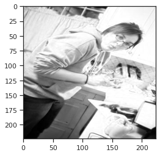

```python
# check to make sure the training data is generated
for i,j in training_generator.__iter__():
  print(i.shape, j[0].shape, j[1].shape)
  plt.imshow(i[0,:,:,0], cmap='gray')
  break
```

```
(60, 224, 224, 3) (60, 21) (60, 5)
```

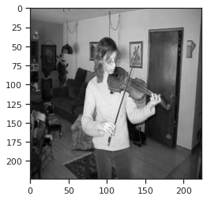

```python
# check to make sure the validation data is generated
for i,j in validation_generator.__iter__():
  print(i.shape, j[0].shape, j[1].shape)
  plt.imshow(i[0,:,:,0], cmap='gray')
  break
```

```python
m_histories = {}

# set the early stopping and monitor the val_loss
def get_callbacks(name):
  return [
    tf.keras.callbacks.EarlyStopping(monitor='val_loss', mode='min',patience=15),
    tf.keras.callbacks.TensorBoard(logdir/name),
  ]
```

Create a simple model using transfer Learning with VGG model

```python
# exclude the top layer of VGG and also set the input shape corresponding to the image_size
# model with multi outputs

# function to create model with diff activation
def get_model_simple(activation_func='relu'):

  base_model = VGG16(input_shape=[224, 224, 3], weights='imagenet', include_top=False)

  # freeze the layers in the base_model
  base_model.trainable = False



  flat_input1 = Flatten()(base_model.output)
  hidden_1_action = Dense(150, activation=activation_func) (flat_input1)
  action_branch = Dense(21, activation='softmax', name="action_output")(hidden_1_action)


  hidden_1_action_class = Dense(30, activation=activation_func) (flat_input1)
  action_class_branch = Dense(5, activation='softmax', name="action_class_output")(hidden_1_action_class)



  simple_model = Model(inputs=base_model.input, outputs=[action_branch, action_class_branch])
  return simple_model
```

Model with elu activation function for the hidden layers

Compile and fit the model

```python
# creates the simple_model with hidden layers having activation_function = 'elu'
simple_model_elu = get_model_simple(activation_func='elu')
```

```python
m_histories['Without_augment_data_elu'] = compile_fit_model(model_name=simple_model_elu, name_callback = 'models/Without_augment_elu', train_data = training_generator, max_epochs=50)
```

Plot the loss for action and action_class

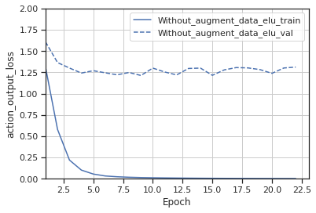

```python
plotter(m_histories, ylim=[0.0, 2], metric = 'action_output_loss')
```

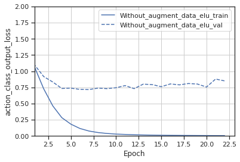

```python
plotter(m_histories, ylim=[0.0, 2], metric = 'action_class_output_loss')
```

Model with relu activation for hidden layers

```python
simple_model_relu = get_model_simple(activation_func='relu')
m_histories['Without_augment_data_relu'] = compile_fit_model(model_name=simple_model_relu, name_callback = 'models/Without_augment_relu', train_data = training_generator, max_epochs=50)
```

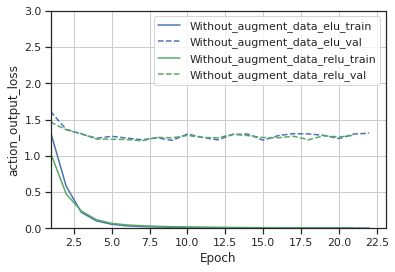

```python
plotter(m_histories, ylim=[0.0, 3], metric = 'action_output_loss')
```

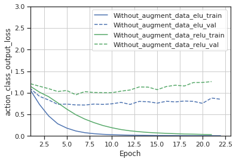

```python
plotter(m_histories, ylim=[0.0, 3], metric = 'action_class_output_loss')
```

From the above plots we can observe that for hidden layers in action branch the activation function = relu is better as it has less overfitting. For the hidden layers in the action_class branch the activation_function = elu is better as it has less overfitting.

# Creating a Complex model

```python
# exclude the top layer of VGG and also set the input shape corresponding to the image_size
# model with multi outputs

# function to create model with diff activation
def get_model_complex():

  base_model = VGG16(input_shape=[224, 224, 3], weights='imagenet', include_top=False)

  # freeze the layers in the base_model
  base_model.trainable = False


# adding a dense layer to action branch
  flat_input1 = Flatten()(base_model.output)
  hidden_1_action = Dense(150, activation='relu') (flat_input1)
  hidden_2_action = Dense(100, activation='relu')(hidden_1_action)
  action_branch = Dense(21, activation='softmax', name="action_output")(hidden_2_action)


  hidden_1_action_class = Dense(30, activation='elu') (flat_input1)
  hidden_2_action_class = Dense(20, activation='elu') (hidden_1_action_class)
  action_class_branch = Dense(5, activation='softmax', name="action_class_output")(hidden_2_action_class)



  complex_model = Model(inputs=base_model.input, outputs=[action_branch, action_class_branch])
  return complex_model
```

**Compile and fit the complex model**

```python
complex_model_histories = {}
complex_model_relu = get_model_complex()
complex_model_histories['Without_augment_data_complex_relu'] = compile_fit_model(model_name=complex_model_relu, name_callback = 'models/Without_augment_complex_relu', train_data = training_generator, max_epochs=50)
```

```
Downloading data from https://storage.googleapis.com/tensorflow/keras-applications/vgg16/vgg16_weights_tf_dim_ordering_tf_kernels_notop.h5
```

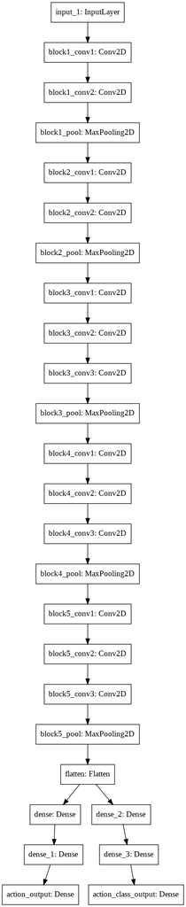

```python
plot_model(complex_model_relu,to_file='new.png')
```

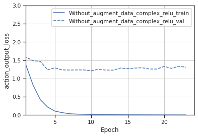

```python
plotter(complex_model_histories, ylim=[0.0, 3], metric = 'action_output_loss')
```

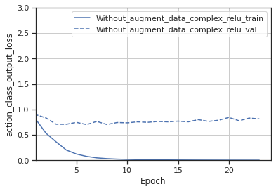

```python
plotter(complex_model_histories, ylim=[0.0, 3], metric = 'action_class_output_loss')
```

After using a complex model overfitting has slightly reduced for action_class_output

Use the augmented training data with complex model for training

```python
# generate the training data with augmentation
training_generator_aug = DataGenerator(x_train ,batch_size=BATCH_SIZE, data_mean=data_mean, data_std=data_std, Augment=True, data_prefix=prefix)
```

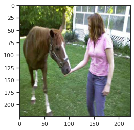

[figure not shown]

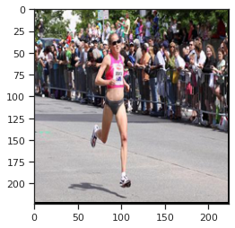

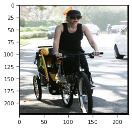

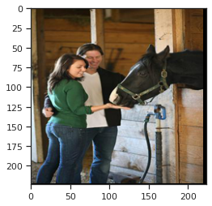

```python
count = 0
for x,y in training_generator_aug.__iter__():
  plt.imshow(x[0,:,:,:])
  count = count + 1
  plt.pause(1)
  if count == 5:
    break
```

```python
complex_model_aug = get_model_complex()
complex_model_histories['With_augment_data_complex'] = compile_fit_model(model_name=complex_model_aug, name_callback = 'models/With_augment_complex_aug', train_data = training_generator_aug, max_epochs=50)
```

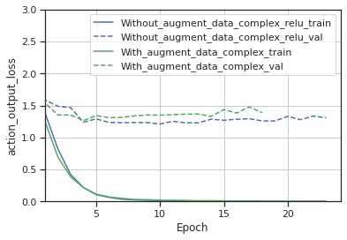

```python
plotter(complex_model_histories, ylim=[0.0, 3], metric = 'action_output_loss')
```

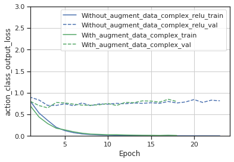

```python
plotter(complex_model_histories, ylim=[0.0, 3], metric = 'action_class_output_loss')
```

After using the augmented dataset the overfitting for action class and action is almost the same. Using saturation and brightness increased the overfitting so I have avoided it.

# Add L2 Regularization to reduce the overfitting

```python
# function to create model with diff activation
def get_model_complex_l2reg(l2_reg_val = 0.001):

  base_model = VGG16(input_shape=[224, 224, 3], weights='imagenet', include_top=False)

  # freeze the layers in the base_model
  base_model.trainable = False


# adding a dense layer to action branch
  flat_input1 = Flatten()(base_model.output)
  hidden_1_action = Dense(150, activation='relu', kernel_regularizer=tf.keras.regularizers.l2(l2_reg_val)) (flat_input1)
  hidden_2_action = Dense(100, activation='relu', kernel_regularizer=tf.keras.regularizers.l2(l2_reg_val))(hidden_1_action)
  action_branch = Dense(21, activation='softmax', name="action_output")(hidden_2_action)


  hidden_1_action_class = Dense(30, activation='elu', kernel_regularizer=tf.keras.regularizers.l2(l2_reg_val)) (flat_input1)
  hidden_2_action_class = Dense(20, activation='elu', kernel_regularizer=tf.keras.regularizers.l2(l2_reg_val)) (hidden_1_action_class)
  action_class_branch = Dense(5, activation='softmax', name="action_class_output")(hidden_2_action_class)



  complex_l2reg_model = Model(inputs=base_model.input, outputs=[action_branch, action_class_branch])
  return complex_l2reg_model
```

```python
l2_reg_histories = {}

model_l2_reg = get_model_complex_l2reg()
l2_reg_histories['With_augment_datagenerator_l2_reg'] = compile_fit_model(model_name=model_l2_reg, name_callback = 'models/With_augment_l2_reg', train_data = training_generator_aug, max_epochs=50)
```

```
Downloading data from https://storage.googleapis.com/tensorflow/keras-applications/vgg16/vgg16_weights_tf_dim_ordering_tf_kernels_notop.h5
```

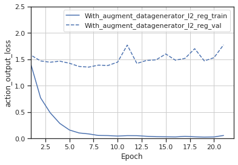

```python
plotter(l2_reg_histories, ylim=[0.0, 2.5], metric = 'action_output_loss')
```

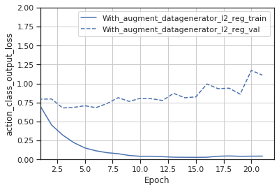

```python
plotter(l2_reg_histories, ylim=[0.0, 2], metric = 'action_class_output_loss')
```

Use l2 regularization with val = 0.010

```python
model_l2_reg_increased = get_model_complex_l2reg(l2_reg_val=0.010)
l2_reg_histories['With_augment__l2_reg_0.010'] = compile_fit_model(model_name=model_l2_reg_increased, name_callback = 'models/With_augment_l2_reg_0.010', train_data = training_generator_aug, max_epochs=50)
```

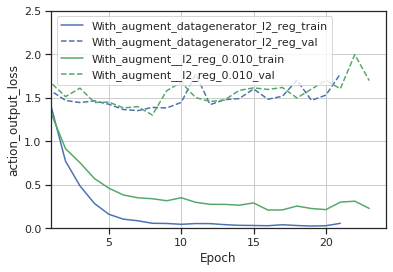

```python
plotter(l2_reg_histories, ylim=[0.0, 2.5], metric = 'action_output_loss')
```

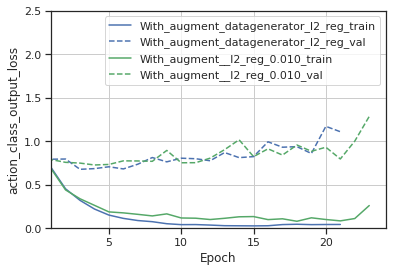

```python
plotter(l2_reg_histories, ylim=[0.0, 2.5], metric = 'action_class_output_loss')
```

Analysis : Overfitting increases after 10 epochs in both action and action_class.

# L1 Regularization

Using l1_regularization with 0.001

```python
# function to create model with diff activation
def get_model_complex_l1reg(l1_reg_val = 0.001):

  base_model = VGG16(input_shape=[224, 224, 3], weights='imagenet', include_top=False)

  # freeze the layers in the base_model
  base_model.trainable = False


# adding a dense layer to action branch
  flat_input1 = Flatten()(base_model.output)
  hidden_1_action = Dense(150, activation='relu', kernel_regularizer=tf.keras.regularizers.l1(l1_reg_val)) (flat_input1)
  hidden_2_action = Dense(100, activation='relu', kernel_regularizer=tf.keras.regularizers.l1(l1_reg_val))(hidden_1_action)
  action_branch = Dense(21, activation='softmax', name="action_output")(hidden_2_action)


  hidden_1_action_class = Dense(30, activation='elu', kernel_regularizer=tf.keras.regularizers.l1(l1_reg_val)) (flat_input1)
  hidden_2_action_class = Dense(20, activation='elu', kernel_regularizer=tf.keras.regularizers.l1(l1_reg_val)) (hidden_1_action_class)
  action_class_branch = Dense(5, activation='softmax', name="action_class_output")(hidden_2_action_class)



  complex_l1reg_model = Model(inputs=base_model.input, outputs=[action_branch, action_class_branch])
  return complex_l1reg_model
```

```python
model_l1_reg = get_model_complex_l1reg(l1_reg_val=0.001)
l2_reg_histories['With_augment__l1_reg'] = compile_fit_model(model_name=model_l1_reg, name_callback = 'models/With_augment_l1_reg', train_data = training_generator_aug, max_epochs=50)
```

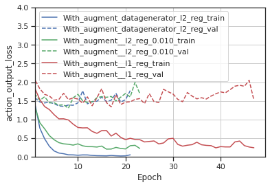

```python
plotter(l2_reg_histories, ylim=[0.0, 4], metric = 'action_output_loss')
```

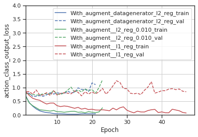

```python
plotter(l2_reg_histories, ylim=[0.0, 4], metric = 'action_class_output_loss')
```

Analysis: From the above plots we can observe that there is less overfitting in L1 regularization compared to L2 regularization. The L2 regularization was sopped at epochs 20 due to early stopping. Even in the case of L1 regularization the model starts overfitting after 20 epochs.

# Adding Dropout to L1 regularization model

```python
# function to create model with diff activation
def get_model_l1reg_dropout(dropout_val = 0.2):

  base_model = VGG16(input_shape=[224, 224, 3], weights='imagenet', include_top=False)

  # freeze the layers in the base_model
  base_model.trainable = False


# adding a dense layer to action branch
  flat_input1 = Flatten()(base_model.output)
  hidden_1_action = Dense(150, activation='relu', kernel_regularizer=tf.keras.regularizers.l1(0.001)) (flat_input1)
  dropout_1 = tf.keras.layers.Dropout(dropout_val)(hidden_1_action)
  hidden_2_action = Dense(100, activation='relu', kernel_regularizer=tf.keras.regularizers.l1(0.001))(dropout_1)
  dropout_2 = tf.keras.layers.Dropout(dropout_val)(hidden_2_action)
  action_branch = Dense(21, activation='softmax', name="action_output")(dropout_2)


  hidden_1_action_class = Dense(30, activation='elu', kernel_regularizer=tf.keras.regularizers.l1(0.001)) (flat_input1)
  dropout_1_action_class = tf.keras.layers.Dropout(dropout_val)(hidden_1_action_class)
  hidden_2_action_class = Dense(20, activation='elu', kernel_regularizer=tf.keras.regularizers.l1(0.001)) (dropout_1_action_class)
  dropout_2_action_class = tf.keras.layers.Dropout(dropout_val)(hidden_2_action_class)
  action_class_branch = Dense(5, activation='softmax', name="action_class_output")(dropout_2_action_class)



  l1reg_dropout_model = Model(inputs=base_model.input, outputs=[action_branch, action_class_branch])
  return l1reg_dropout_model
```

```python
l1_reg_dropout_histories = {}
model_l1_dropout = get_model_l1reg_dropout()
l1_reg_dropout_histories['augment_l1reg_dropout'] = compile_fit_model(model_name=model_l1_dropout, name_callback = 'models/model_l1_dropout', train_data = training_generator_aug, max_epochs=50)
```

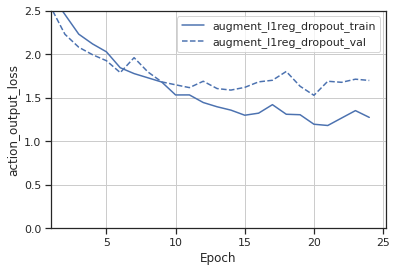

```python
plotter(l1_reg_dropout_histories, ylim=[0.0, 2.5], metric = 'action_output_loss')
```

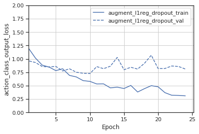

```python
plotter(l1_reg_dropout_histories, ylim=[0.0, 2], metric = 'action_class_output_loss')
```

Change dropout to 0.4

```python
model_l1_dropout_increased = get_model_l1reg_dropout(dropout_val=0.4)
l1_reg_dropout_histories['augment_l1reg_dropout_increased'] = compile_fit_model(model_name=model_l1_dropout_increased, name_callback = 'models/model_l1_dropout_increased', train_data = training_generator_aug, max_epochs=50)
```

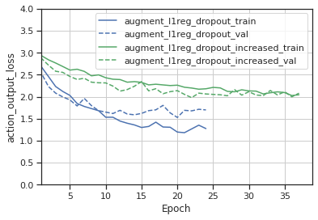

```python
plotter(l1_reg_dropout_histories, ylim=[0.0, 4], metric = 'action_output_loss')
```

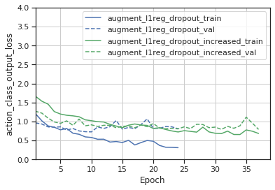

```python
plotter(l1_reg_dropout_histories, ylim=[0.0, 4], metric = 'action_class_output_loss')
```

After increasing the dropout from 0.2 to 0.4, the overfitting has reduced considerably. But using dropout 0.4 reduces the accuracy of the model. I can instead use dropout with 0.2 and stop training the model after 10 epochs. In all the polts we can clearly obeserve that after 10 epochs the overfitting is increasing.

Train the model again with dropout = 0.2 and max epochs = 10

```python
dropout_less_epochs_histories = {}
model_less_epochs_dropout = get_model_l1reg_dropout(dropout_val=0.2)
dropout_less_epochs_histories['l1reg_dropout_less_epochs_adam'] = compile_fit_model(model_name=model_less_epochs_dropout, name_callback = 'models/model_l1_dropout_less_epochs_adam', train_data = training_generator_aug, max_epochs=10)
```

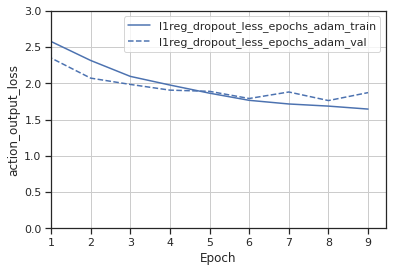

```python
plotter(dropout_less_epochs_histories, ylim=[0.0, 3], metric = 'action_output_loss')
```

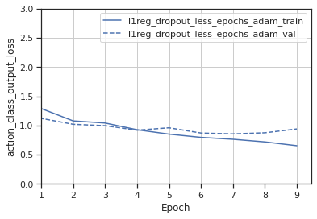

```python
plotter(dropout_less_epochs_histories, ylim=[0.0, 3], metric = 'action_class_output_loss')
```

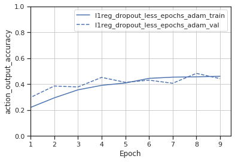

```python
plotter(dropout_less_epochs_histories, ylim=[0.0, 1], metric = 'action_output_accuracy')
```

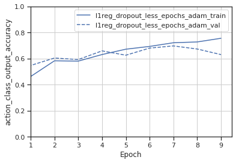

```python
plotter(dropout_less_epochs_histories, ylim=[0.0, 1], metric = 'action_class_output_accuracy')
```

Using SGD Optimizer

```python
def compile_fit_model_SGD_opt(model_name, name_callback, learning_rate=0.001, loss_function='categorical_crossentropy', perf_metric='accuracy', train_data = training_generator, max_epochs=50):

  STEPS_PER_EPOCH = TRAIN_DATA_LEN//BATCH_SIZE
  lr_schedule = tf.keras.optimizers.schedules.InverseTimeDecay(
    learning_rate,
    decay_steps=STEPS_PER_EPOCH*1000,
    decay_rate=1,
    staircase=False)


  model_name.compile(optimizer=tf.keras.optimizers.SGD(lr_schedule),
                     loss={
                  'action_output': loss_function,
                  'action_class_output': loss_function},
              metrics={
                  'action_output': perf_metric,
                  'action_class_output': perf_metric
              }
                  )

  history = model_name.fit(
      train_data,
      steps_per_epoch = STEPS_PER_EPOCH,
      epochs=max_epochs,
      validation_data=validation_generator,
      callbacks=get_callbacks(name_callback),
      verbose=1)

  return history
```

```python
model_less_epochs_dropout_SGD = get_model_l1reg_dropout(dropout_val=0.2)
dropout_less_epochs_histories['l1reg_dropout_less_epochs_SGD'] = compile_fit_model_SGD_opt(model_name=model_less_epochs_dropout_SGD, name_callback = 'models/model_l1_dropout_less_epochs_SGD', train_data = training_generator_aug, max_epochs=10)
```

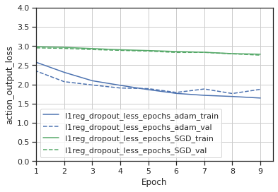

```python
plotter(dropout_less_epochs_histories, ylim=[0.0, 4], metric = 'action_output_loss')
```

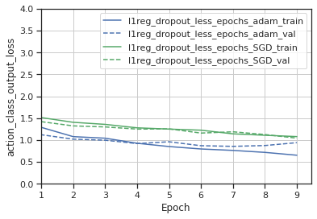

```python
plotter(dropout_less_epochs_histories, ylim=[0.0, 4], metric = 'action_class_output_loss')
```

# Evaluate on the test set

```python
# generate the test set
test_generator = DataGenerator(x_test  ,batch_size=BATCH_SIZE, data_mean=data_mean, data_std=data_std, Augment=False, data_prefix=prefix)
```

```
(60, 224, 224, 3) (60, 21) (60, 5)
```

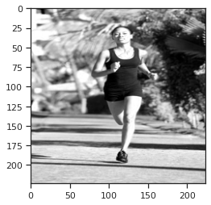

```python
# check to make sure the test data is generated
for i,j in test_generator.__iter__():
  print(i.shape, j[0].shape, j[1].shape)
  plt.imshow(i[0,:,:,0], cmap='gray')
  break
```

Eavluate the model_less_epochs_dropout model on test generator

```python
print(model_less_epochs_dropout.evaluate(test_generator))
```

```
[4.778380870819092, 1.7443933486938477, 0.8846776485443115, 0.5023809671401978, 0.699999988079071]
```

# Predict on test data

```python
df_test = pd.read_csv('/content/drive/MyDrive/S40AR_test_data.csv')
```

```python
import PIL

# extract all the images in a matrix
# length of the test data
length_test = len(df_test)
sparse_matrix = np.empty((length_test, *(224,224,3)))
images_list = list()

counter=0

for img_name in df_test['FileName']:
  image = PIL.Image.open(prefix+img_name)

  # add the image to image_list()
  images_list.append(img_name)
  image = image.resize((224,224))
  if len(np.asarray(image).shape)==3:

    sparse_matrix[counter,]=np.asarray(image)/255
    counter=counter+1
  else:
    # to avoid the corrupted image Img_3201.jpg

    sparse_matrix[counter,]= np.expand_dims(np.asarray(image),2)/255
    counter = counter + 1
```

```python
# store all the predictions in ypred
ypred = model_less_epochs_dropout.predict(sparse_matrix)
```

```python
iterate_len = len(ypred[0])
prediction_df = list()
filename = list()
action= list()
action_class= list()


# 3 seperate lists to store filename, action and action_class
for row in range(iterate_len):
   filename.append(images_list[row]),
   action.append(l1.inverse_transform([  np.argmax(ypred[0][row])  ])[0]),
   action_class.append(l2.inverse_transform([  np.argmax(ypred[1][row])  ])[0])
```

Create the prediction.csv dataframe

```python
predictions_data = pd.DataFrame(
    {'FileName': filename,
     'action': action,
     'action_class': action_class
    })
```

```python
predictions_data.to_csv('s3828740_predictions1.csv', index=False)
```